# 中国银行业经营现状

邱飞

万里学院

# 银行信贷收支表分析

资金来源部分

资金使用部分

# 单位活期存款

期初数 0.220461，期末数 0.1643948

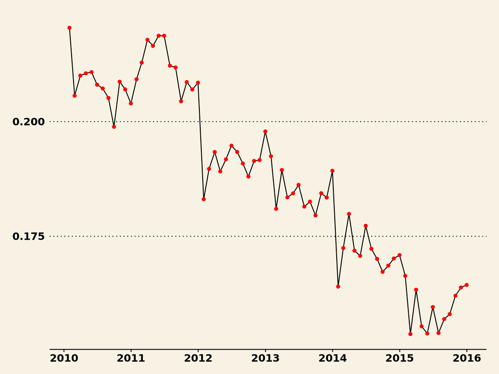

# 单位活期存款的意义

- 单位活期存款反应了企业的资金紧张程度
- 单位活期存款比重不断下降，表明企业的资金面一直处于紧张状态

# 单位定期存款

期初数 NA，期末数 0.1080967

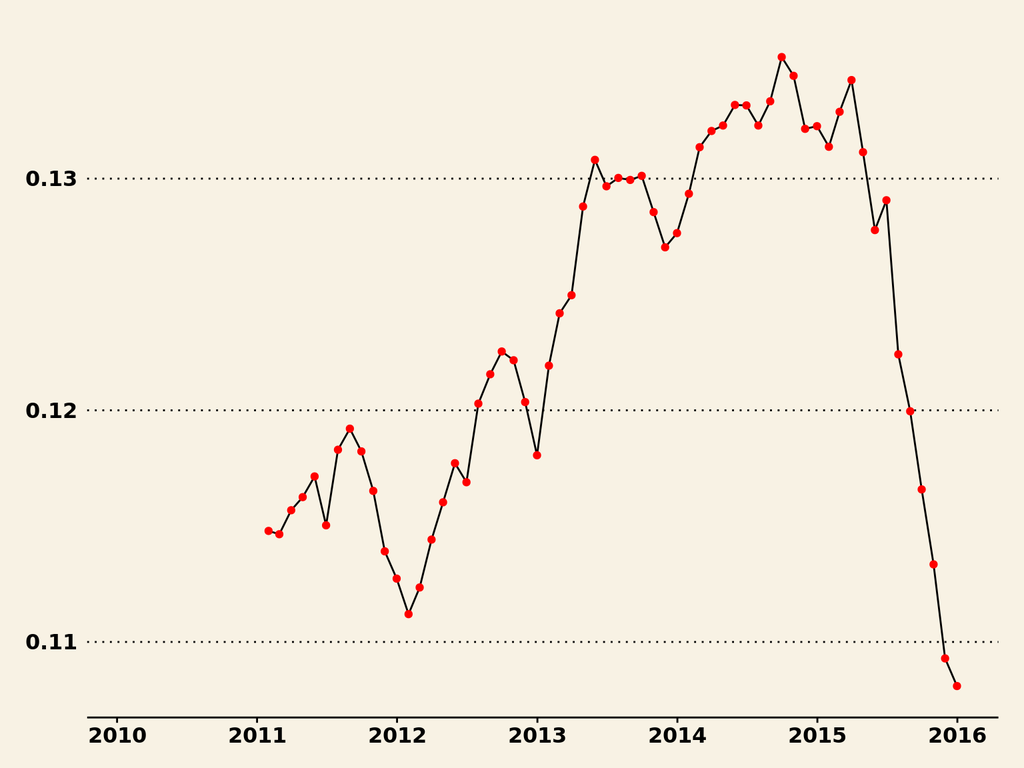

# 单位存款

期初数 0.4734616，期末数 0.3834459

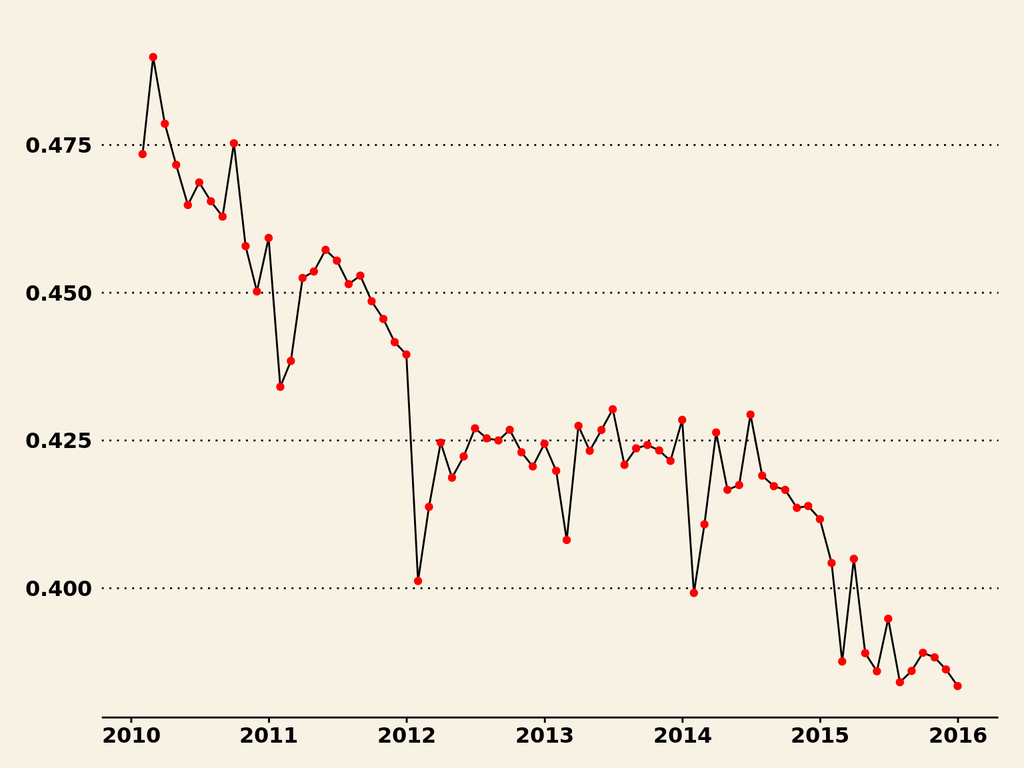

# 同业存款

期初数 NA，期末数 0.0173758

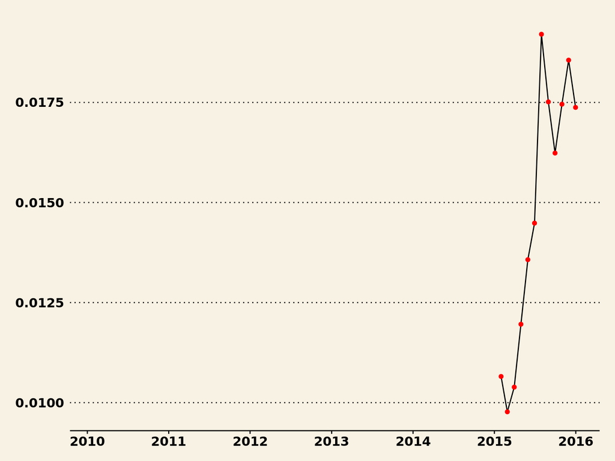

# 回购

期初数 NA，期末数 0.0101978

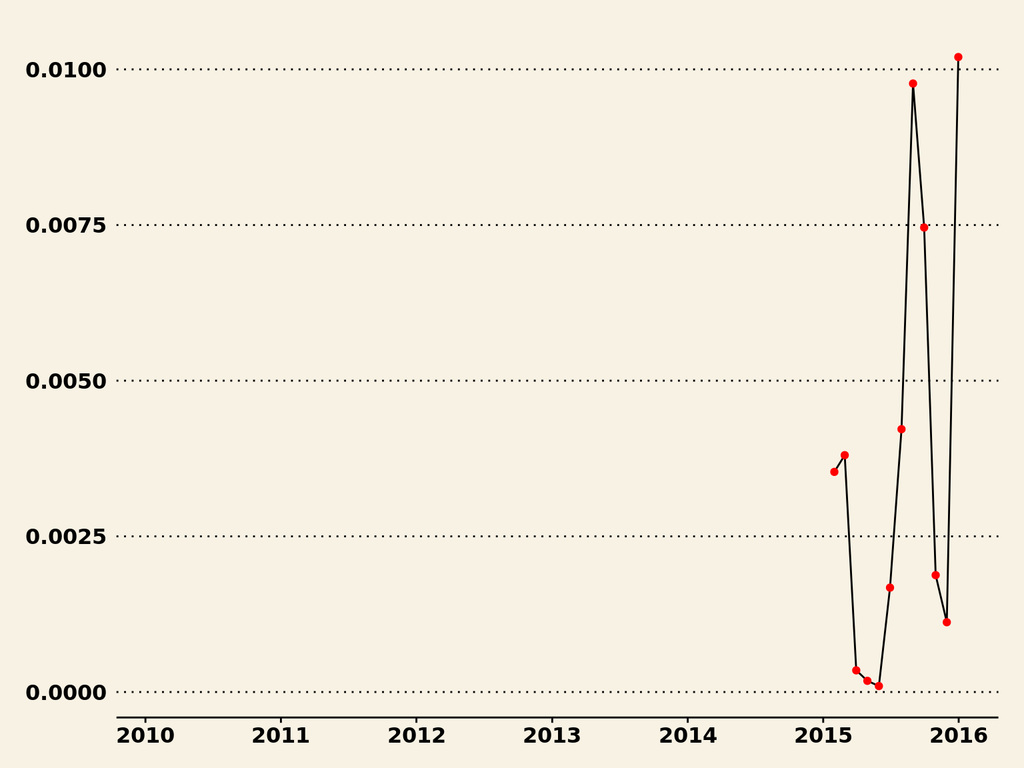

# 个人存款

期初数 NA，期末数 0.4129799

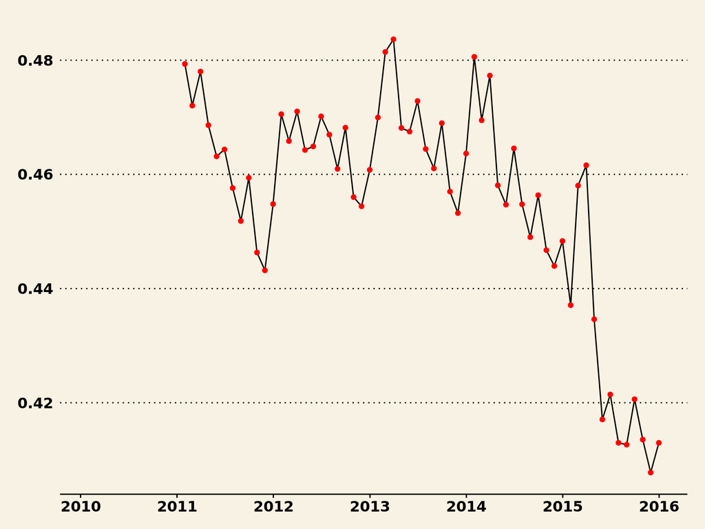

# 储蓄存款

期初数 NA，期末数 0.2051782

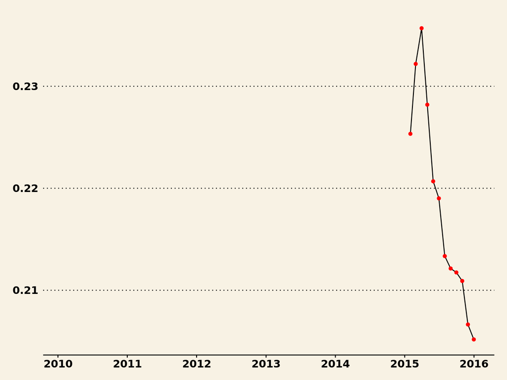

# 个人结构存款

期初数 NA，期末数 0.0101821

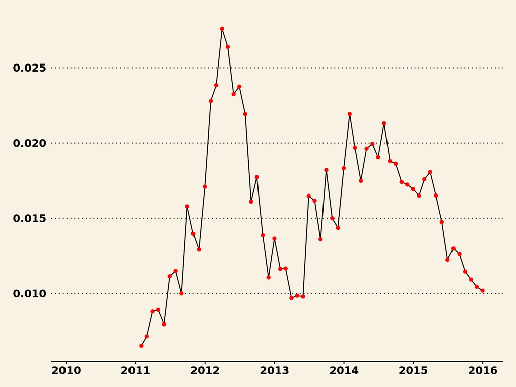

- 个人结构存款对应银行理财产品资金
- 个人存款占比下降，主要是存款向理财资金的转变

# 全国性银行储蓄存款占总存款的比重

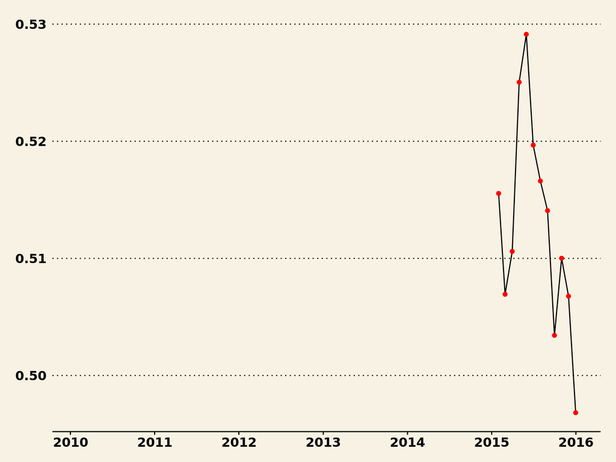

# 银行体系资金来源的稳定性在下降

- 大型银行的核心存款占总存款的比重降到了50%以下，这说明我国银行体系资金来源的稳定性在下降。

# 存款市场的垄断程度

期初数 0.8489092，期末数 0.8094536。

存款市场的垄断程度在持续降低。

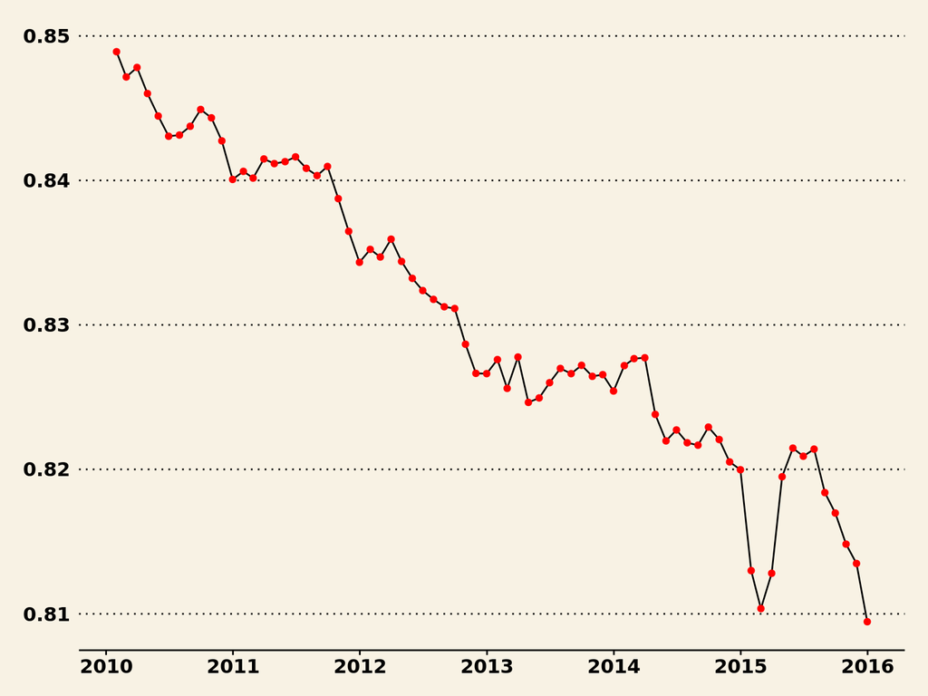

# 金融债券

期初数 0.0089466，期末数 0.0103029

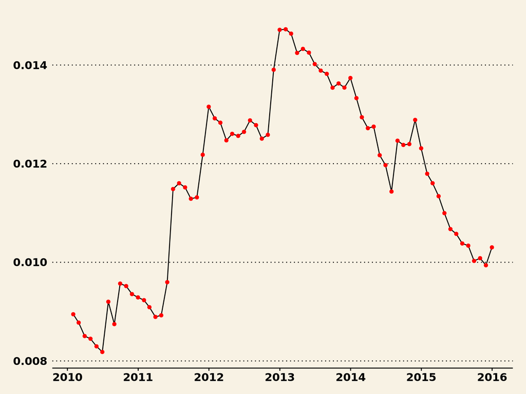

# 金融债券的垄断势力

期初数 0.0800825，期末数 0.0806703。

这说明四大行较少进行金融债券融资。

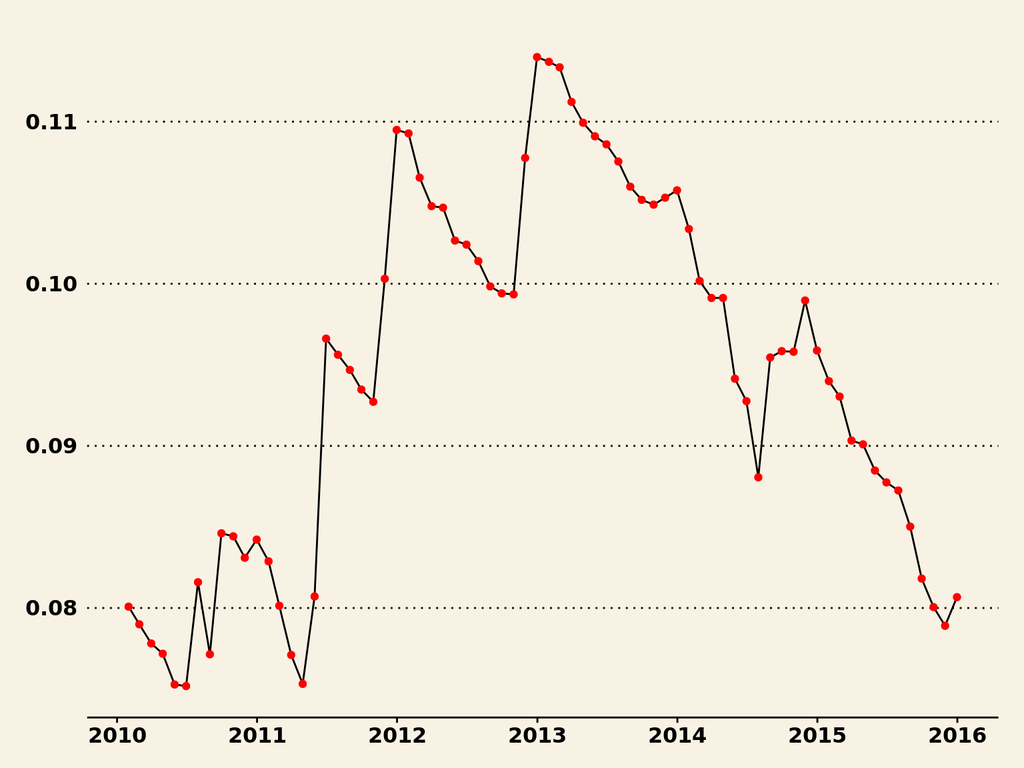

# 其他负债的垄断性

期初数 NA，期末数 0.7287364。

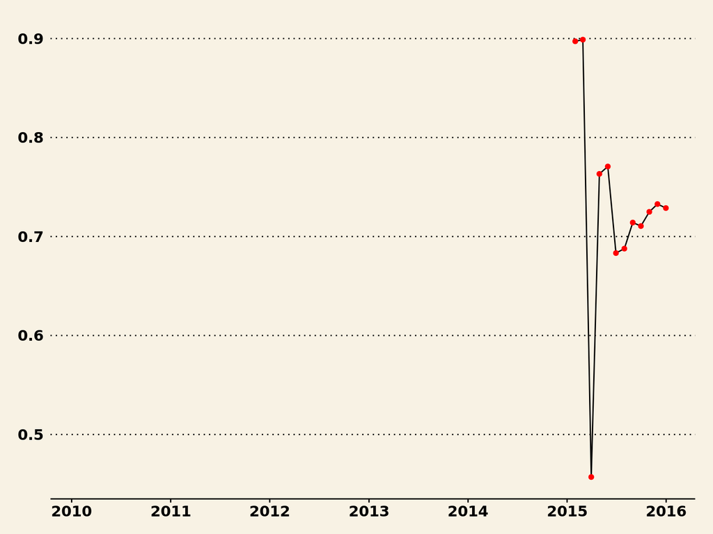

# 其他负债方式的垄断

- 其他负债的垄断势力高，
- 这说明四大行在金融债券之外，实现负债结构的多元化

# 国外存款

期初数 NA，期末数 0.006829

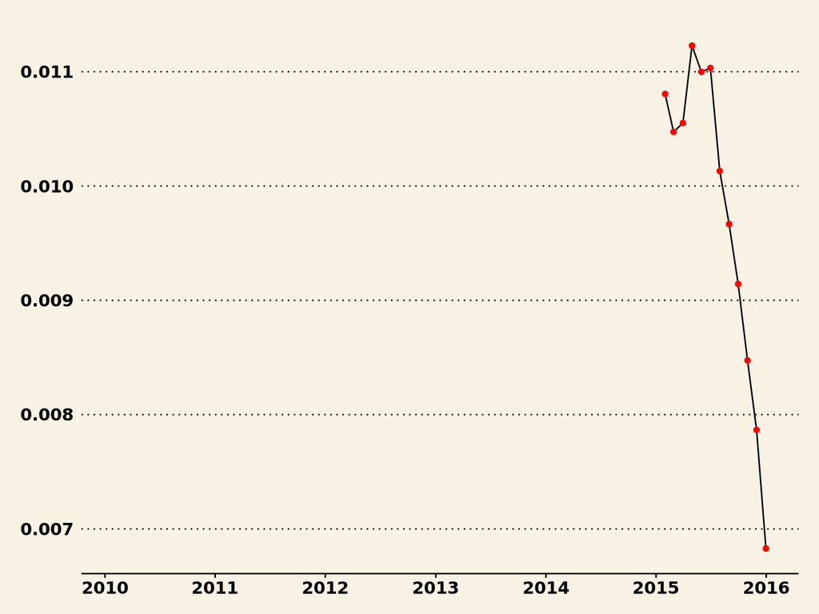

# 非存款金融机构的存款

期初数 NA，期末数 0.0637589

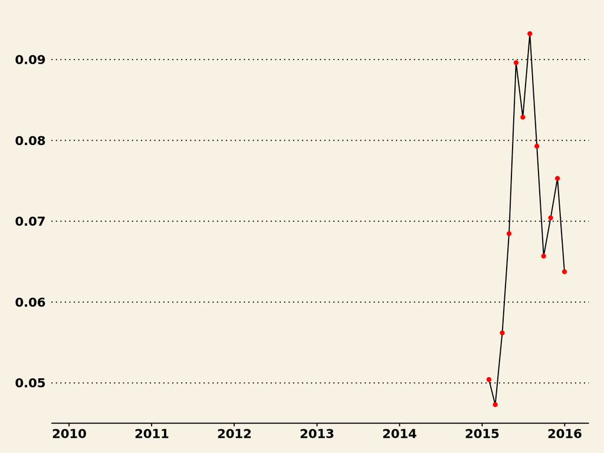

# 其他资金来源

期初数 0.0473484，期末数 0.0891882

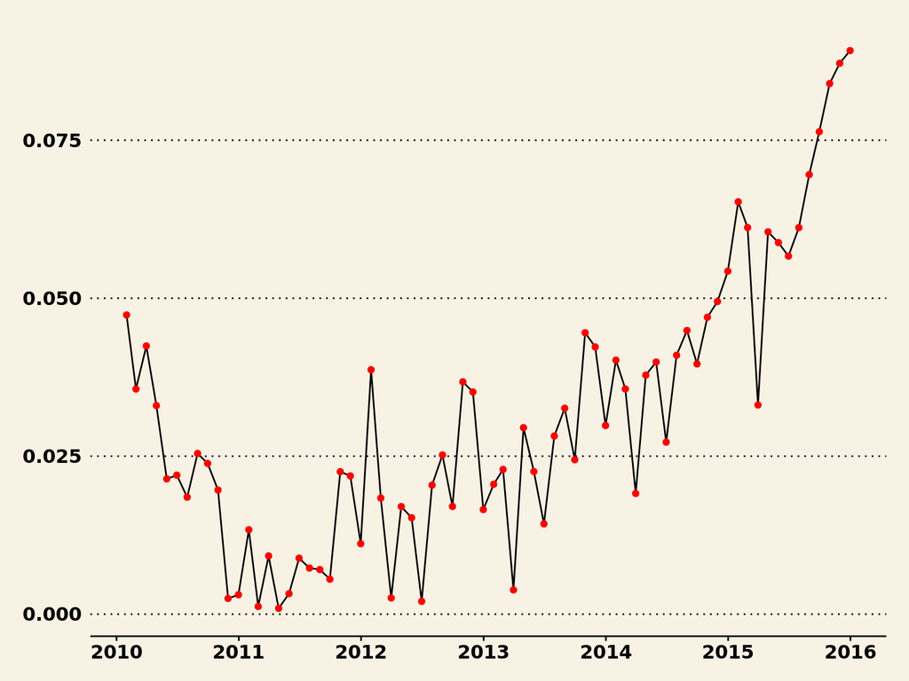

# 贷款总额占资金使用的比重

期初数 0.5541683，期末数 0.572931

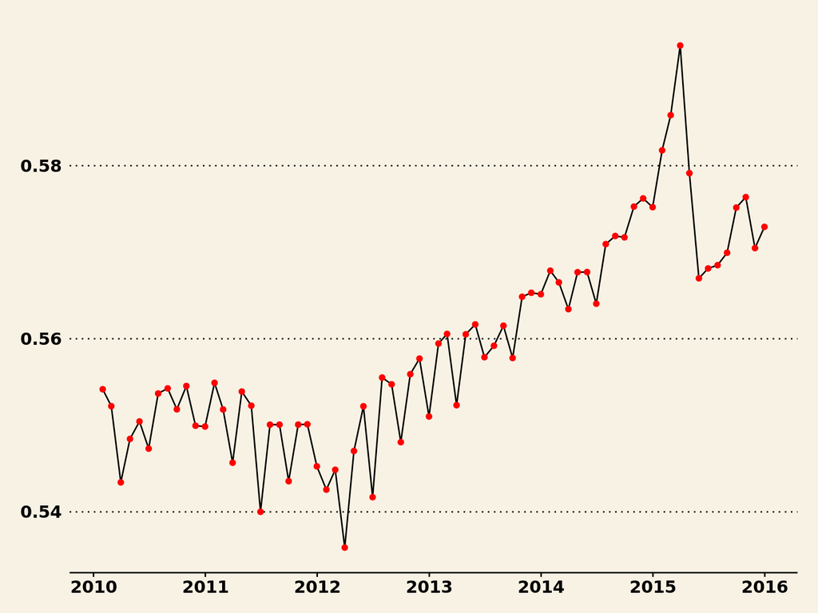

# 贷款增速

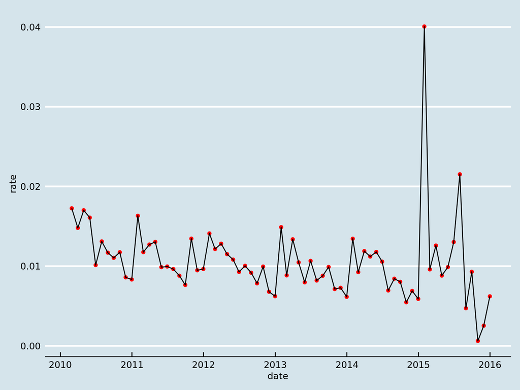

# 增幅的意义

- 贷款月度增速均值为1%，也就是说年增速接近13%，
- 高于同期GDP增速。
- 贷款增幅与GDP之间有何关系？

# 各国信贷占GDP的比重的比较

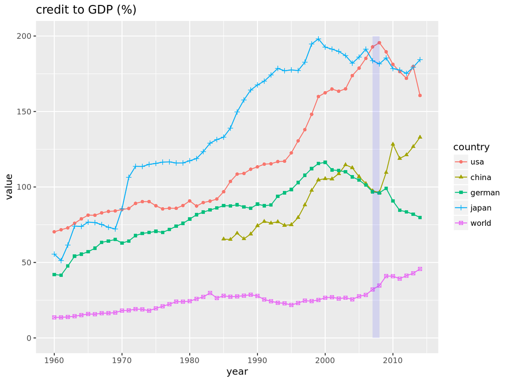

# 中国信贷占GDP的比重不是最高的

- 最上面蓝色与红色分别是日本和美国的数据,
- 可以看到美国信贷占GDP的比重在2008年达到最大,也是在这一年,次贷危机全面爆发。

# 2008年后开始高速加杠杆

# 一个值得探索的问题

- 目前世界的信贷占GDP的比重处在历史上的最高水平
- 世界1984-2005之间,世界总体的信贷占GDP的比重是比较平稳的,此后一直上升.

# 四大行贷款占比

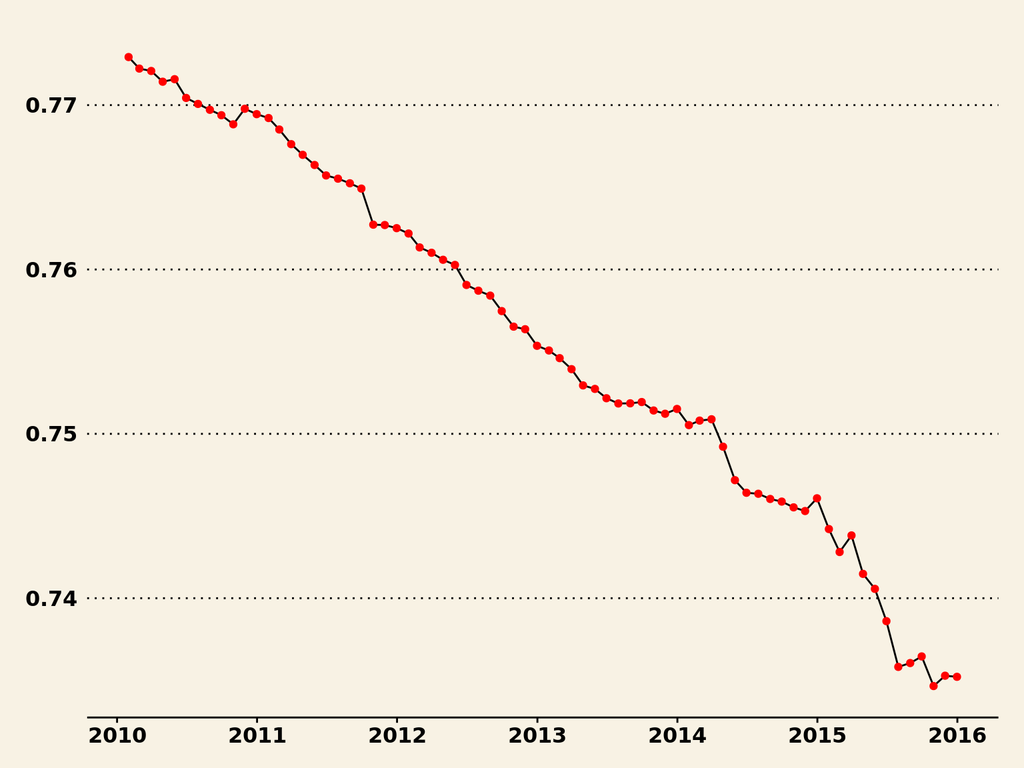

# 贷款市场垄断性减轻

- 四大行占款占比直线下降
- 这表明贷款市场长垄断性在下降
- 这也是目前各大行积极开展新业务的原因，传统的贷款业务竞争越来越激烈

# 短期贷款

期初数 0.1432925，期末数 0.1709168。

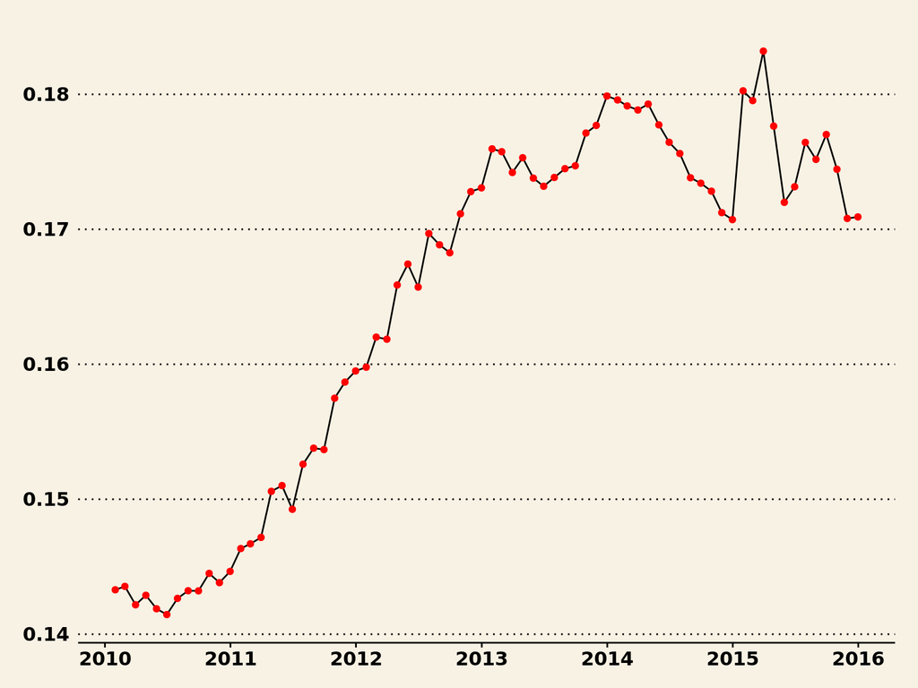

# 长期贷款

期初数 0.3804862，期末数 0.3755655

长期贷款比重呈现出波动状态，这可能与投资周期的波动有关。

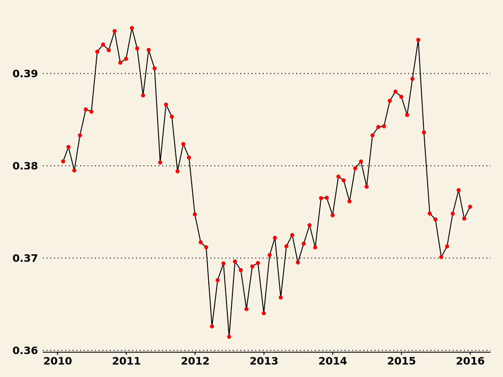

# 票据融资

期初数 0.0301948，期末数 0.0245072

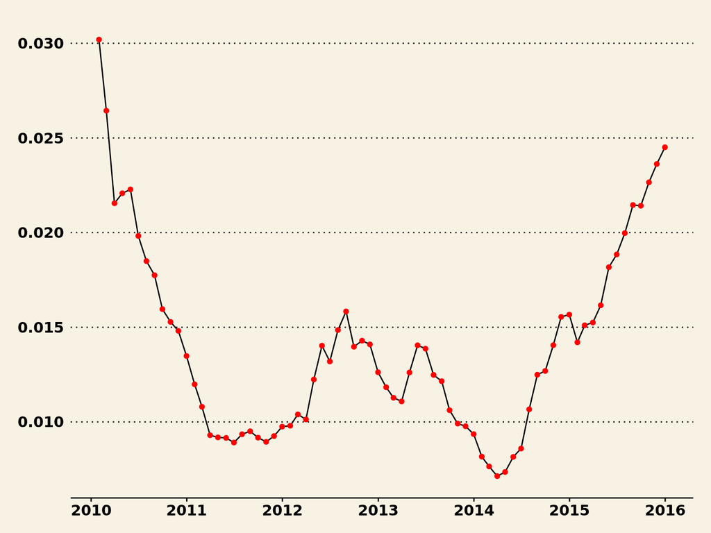

# 证券投资

期初数 0.2898297，期末数 0.225982

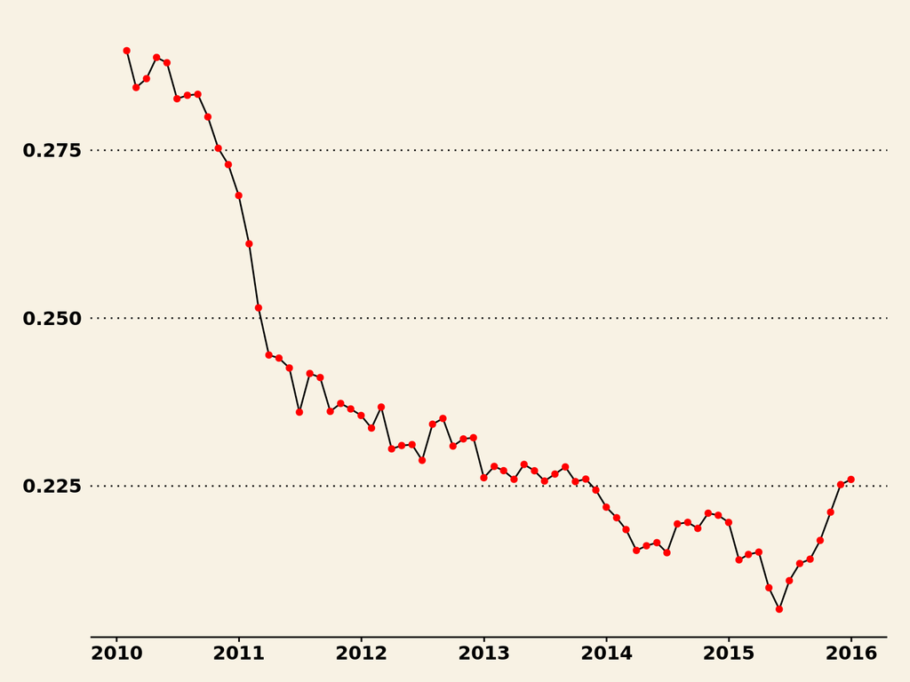

# 股权投资

期初数 NA，期末数 0.0113252

商业银行法规定，商业银行在中国境内不得对非金融企业进行股权投资。

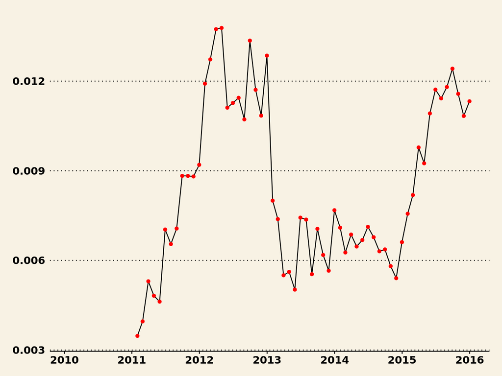

# 逆回购

期初数 NA，期末数 0.0263105

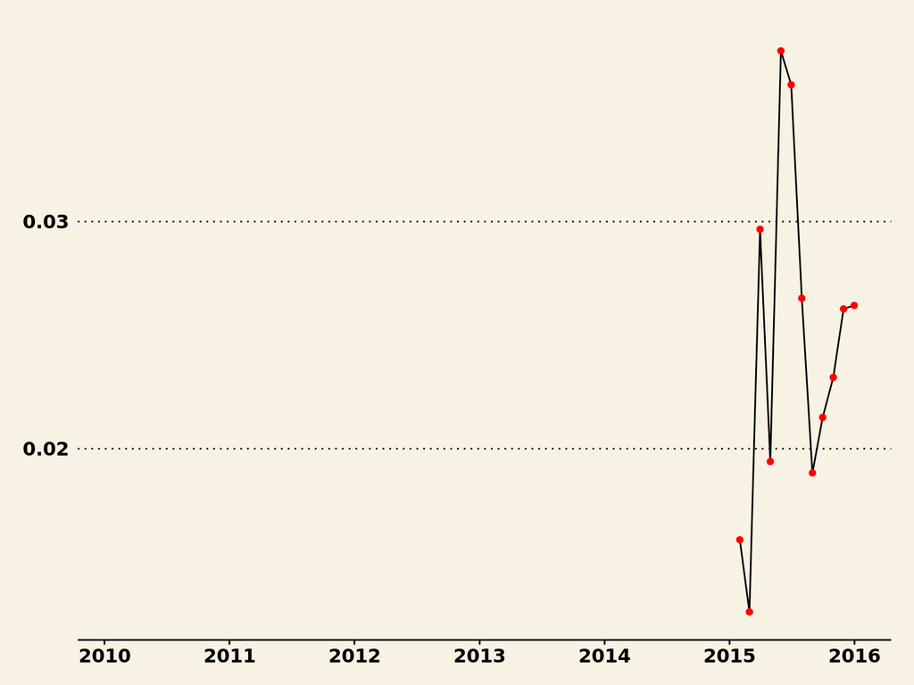

# 准备金

期初数 0.1304086，期末数 0.1266342

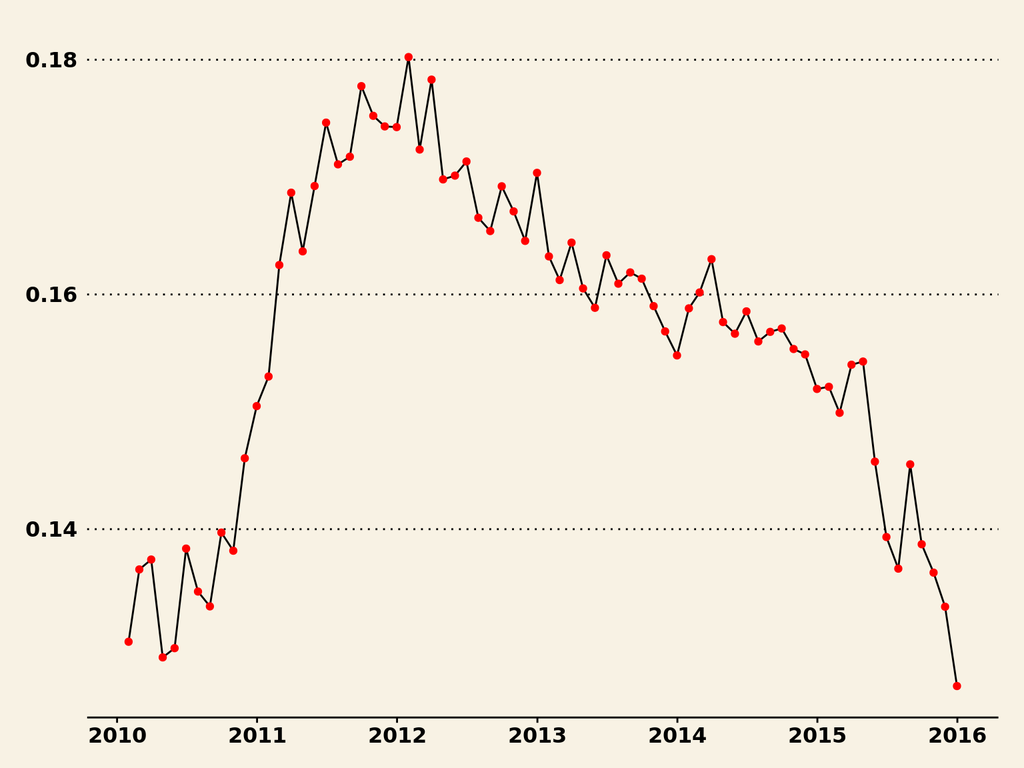

# 实体经济与准备金

- 从商业银行在央行的储备可以看出货币政策态度的变化，
- 央行本来是为了防止流动性过剩而提高准备金率的，
- 但是随着实体经济的下行，央行随之下降准备金水平来刺激经济。

# 同业业务

期初数 NA，期末数 0.0368171

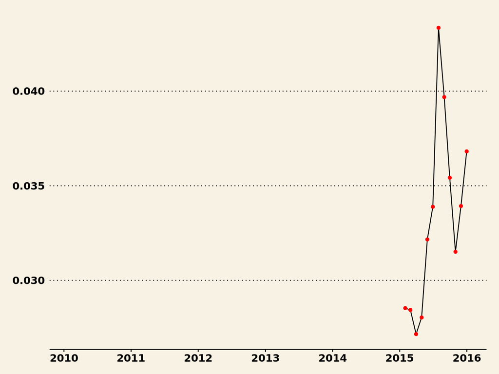

# 监管部门对同业的关注

- 同业数据大幅波动，是因为这里存在着创新与监管的博弈
- 中国分业监管的模式下，商业银行的很多金融“创新”是通过同业业务进行的